# What influences our physical and mental health?

# R Packages and Setup

```r
library(knitr); library(rmdformats)
library(here); library(janitor); library(magrittr)
library(rms); library(broom); library(patchwork)

library(tidyverse)
```

# 1 Data Source

This project utilizes data from the PLACES Project 2020 release. The data contain county-level estimates of 27 health-related measures (5 on chronic disease-related unhealthy behaviors, 13 on health outcomes, and 9 on preventative service utilization). There are 3,142 counties included in the data set, covering the 50 states and District of Columbia of the United States. These data are provided by the Centers for Disease Control and Prevention (CDC), Division of Population Health, Epidemiology and Surveillance Branch. It is accessible to the general public and can be accessed [here](https://chronicdata.cdc.gov/500-Cities-Places/PLACES-Local-Data-for-Better-Health-County-Data-20/swc5-untb) [1].

Using the 2017 and 2018 Behavioral Risk Factor Surveillance System (BRFSS) survey results, researchers utilized multilevel regression and post-stratification (MRP) to produce small area estimates of 27 measures in each county. This approach is described by Zhang et al. (2014) [2] and Zhang et al. (2015) [3]. BRFSS is an annual telephone survey, which uses a standardized questionnaire to ask participants across the country about their health risk activities. It is sponsored by most divisions of the CDC, along with other federal agencies. These data are collected with the purpose of assisting organizations in the building and targeting of health promotion activities.

# 2 The Subjects

Each row in this data set represents a county within the United States.

# 3 Loading and Tidying the Data

We’ll start by loading the PLACES data set from the `data` directory in our project directory. This file is completely unchanged from the original downloaded file from the [PLACES website](https://chronicdata.cdc.gov/500-Cities-Places/PLACES-Local-Data-for-Better-Health-County-Data-20/swc5-untb).

## 3.1 Loading the Raw Data

```r
counties_raw <- read.csv(here("data",
                              "PLACES__Local_Data_for_Better_Health__County_Data_2020_release.csv"),
                         na.strings = c(""))
```

## 3.2 Cleaning the Data

In this section, we’ll work through taking the raw PLACES 2020 data set to a clean tibble that only contains our variables of interest.

### 3.2.1 Extracting variables of interest

To start cleaning our data set, we’ll filter the raw data to extract the measures and data types that we are interested in.

First, we’ll remove any row that has a missing value for `LocationName`. Based on the population size for these rows (>300 million), they appear to represent an aggregate for the entire United States. As such, they do not represent the county-level data we are assessing with this project. Then, we’ll filter the `Data_Value_Type` variable to include only `Age-adjusted prevalence`, and we’ll filter the `Measure` column to include only the following variables of interest:

- `Physical health not good for >=14 days among adults aged >=18 years`
- `Visits to doctor for routine checkup within the past year among adults aged >=18 years`
- `Arthritis among adults aged >=18 years`
- `Stroke among adults aged >=18 years`
- `Chronic kidney disease among adults aged >=18 years`
- `Mental health not good for >=14 days among adults aged >=18 years`
- `No leisure-time physical activity among adults aged >=18 years`
- `Sleeping less than 7 hours among adults aged >=18 years`
- `Binge drinking among adults aged >=18 years`

Additionally, we’ll use mutate to create a new column, `CountyState_ID`, which will serve as the unique identifier for each entry, using `paste` to combine the county name (`LocationName`) and state abbreviation (`StateAbbr`) variables.

```r
counties_clean <- counties_raw %>%
  filter(!(is.na(LocationName))) %>%
  filter(Data_Value_Type == "Age-adjusted prevalence") %>%
  filter(Measure %in% c("Physical health not good for >=14 days among adults aged >=18 years",
                        "Visits to doctor for routine checkup within the past year among adults aged >=18 years",
                        "Arthritis among adults aged >=18 years",
                        "Stroke among adults aged >=18 years",
                        "Chronic kidney disease among adults aged >=18 years",
                        "Mental health not good for >=14 days among adults aged >=18 years",
                        "No leisure-time physical activity among adults aged >=18 years",
                        "Sleeping less than 7 hours among adults aged >=18 years",
                        "Binge drinking among adults aged >=18 years")) %>%
  mutate(CountyState_ID = paste(LocationName, StateAbbr, sep = "-"))
```

### 3.2.2 Formatting tibble

Next, we’ll adjust the format of the tibble so that each row is a single county, while each column is a metric of interest. To do this, we’ll use `pivot_wider` so that each unique `Measure` is a column, each row is a unique `CountyState_ID`, and the data are from `Data_Value`. Here, we’ll also confirm that the `CountyState_ID` is unique for each row by showing that the number of rows in the tibble is the same as the number of unique values in the `CountyState_ID` column.

```r
counties_clean <- counties_clean %>%
  pivot_wider(id_cols = CountyState_ID, names_from = Measure, values_from = Data_Value)


paste("Number of rows:", nrow(counties_clean))
```

```
[1] "Number of rows: 3142"
```

```r
paste("Number of unique CountyState_ID rows:", length(unique(counties_clean$CountyState_ID)))
```

```
[1] "Number of unique CountyState_ID rows: 3142"
```

### 3.2.3 Shorten column names

Let’s shorten the column names for ease of use and readability. They will be adjusted as follows:

- `Physical health not good for >=14 days among adults aged >=18 years` –> `Poor_PHealth`
- `Visits to doctor for routine checkup within the past year among adults aged >=18 years` –> `Doc_Visit`
- `Arthritis among adults aged >=18 years` –> `Arthritis`
- `Stroke among adults aged >=18 years` –> `Stroke`
- `Chronic kidney disease among adults aged >=18 years` –> `CKD`
- `Mental health not good for >=14 days among adults aged >=18 years` –> `Poor_MHealth`
- `No leisure-time physical activity among adults aged >=18 years` –> `No_Leisure_Exer`
- `Sleeping less than 7 hours among adults aged >=18 years` –> `Less_Sleep`
- `Binge drinking among adults aged >=18 years` –> `Binge_Drinking`

```r
colnames(counties_clean) <- c("CountyState_ID", "Poor_PHealth", "Doc_Visit", "Arthritis", "Stroke", "CKD", "Poor_MHealth", "No_Leisure_Exer", "Less_Sleep", "Binge_Drinking")
```

### 3.2.4 Convert `Poor_MHealth`, `Doc_Visit`, and `No_Leisure_Exercise` into categorical variables

Since all of our variables are continuous, we’ll need to convert a few of them into categorical to meet the requirements of this assignment. Using `mutate`, we’ll convert `Poor_MHealth` into a binary variable called `Poor_MHealth_High`, while `Doc_Visit` and `No_Leisure_Exer` will be converted into ordered categorical variables called `Doc_Visit_Quar` and `No_Leisure_Exer_Quin`, respectively. `Poor_MHealth_High` will be categorized based on counties that are above and below the median value for the `Poor_MHealth` variable. `Doc_Visit_Quar` will be based whether the county is in the first, second, third, or fourth quartile of the `Doc_Visit` variable. `No_Leisure_Exer_Quin` will be based on being in the first, second, third, fourth, or fifth quintile of the `No_Leisure_Exer`variable. These three new variables will be converted to ordered factors.

```r
counties_clean <- counties_clean %>%
  mutate(Poor_MHealth_High = case_when(Poor_MHealth < median(Poor_MHealth) ~ 0,
                                               Poor_MHealth >= median(Poor_MHealth) ~ 1),
         Doc_Visit_Quar = case_when(Doc_Visit < quantile(Doc_Visit, 0.25) ~ 1,
                                            Doc_Visit >= quantile(Doc_Visit, 0.25) &
                                              Doc_Visit < quantile(Doc_Visit, 0.5)  ~ 2,
                                            Doc_Visit >= quantile(Doc_Visit, 0.5) &
                                              Doc_Visit < quantile(Doc_Visit, 0.75)  ~ 3,
                                            Doc_Visit >= quantile(Doc_Visit, 0.75) ~ 4),
         No_Leisure_Exer_Quin = case_when(No_Leisure_Exer < quantile(No_Leisure_Exer, 0.2) ~ 1,
                                              No_Leisure_Exer >= quantile(No_Leisure_Exer, 0.2) &
                                                No_Leisure_Exer < quantile(No_Leisure_Exer, 0.4) ~ 2,
                                              No_Leisure_Exer >= quantile(No_Leisure_Exer, 0.4) &
                                                No_Leisure_Exer < quantile(No_Leisure_Exer, 0.6) ~ 3,
                                              No_Leisure_Exer >= quantile(No_Leisure_Exer, 0.6) &
                                                No_Leisure_Exer < quantile(No_Leisure_Exer, 0.8) ~ 4,
                                              No_Leisure_Exer >= quantile(No_Leisure_Exer, 0.8) ~ 5)) %>%
  mutate(Poor_MHealth_High = factor(Poor_MHealth_High, ordered = TRUE),
         Doc_Visit_Quar = factor(Doc_Visit_Quar, ordered = TRUE),
         No_Leisure_Exer_Quin = factor(No_Leisure_Exer_Quin, ordered = TRUE))
```

We’ll take a quick look at the new variables to ensure that our code accomplished what we expected it to. For each new categorical variable, we will group the data set by the new variable, and use `summarise` to demonstrates that each group contains close to the same number of samples (`n`), and the minimum value (`min`) and maximum value (`max`) for each group are ordered appropriately.

```r
counties_clean %>%
  group_by(Poor_MHealth_High) %>%
  summarise(n = length(Poor_MHealth),
            min = min(Poor_MHealth),
            max = max(Poor_MHealth))
```

```
# A tibble: 2 x 4
  Poor_MHealth_High     n   min   max
* <ord>             <int> <dbl> <dbl>
1 0                  1554   8.8  15
2 1                  1588  15.1  24.7
```

```r
counties_clean %>%
  group_by(Doc_Visit_Quar) %>%
  summarise(n = length(Doc_Visit),
            min = min(Doc_Visit),
            max = max(Doc_Visit))
```

```
# A tibble: 4 x 4
  Doc_Visit_Quar     n   min   max
* <ord>          <int> <dbl> <dbl>
1 1                766   6.5  15.6
2 2                782  15.7  17.6
3 3                776  17.7  19.8
4 4                818  19.9  28.7
```

```r
counties_clean %>%
  group_by(No_Leisure_Exer_Quin) %>%
  summarise(n = length(No_Leisure_Exer),
            min = min(No_Leisure_Exer),
            max = max(No_Leisure_Exer))
```

```
# A tibble: 5 x 4
  No_Leisure_Exer_Quin     n   min   max
* <ord>                <int> <dbl> <dbl>
1 1                      625   7    11.2
2 2                      620  11.3  12.7
3 3                      630  12.8  14.1
4 4                      618  14.2  15.7
5 5                      649  15.8  29.2
```

Seeing that our data pass this sanity check, we’ll remove the continuous `Doc_Visit`, `No_Leisure_Exer`, and `Poor_MHealth` variables, because they won’t be used in our future analysis. We’ll also arrange the columns so that the leftmost column is the identifier, followed by the regression outcomes, followed by the regression inputs.

```r
counties_clean <- counties_clean %>%
  select(-c(Doc_Visit, No_Leisure_Exer, Poor_MHealth)) %>%
  select(CountyState_ID, Poor_PHealth, Poor_MHealth_High, Arthritis, Stroke,
         CKD, Less_Sleep, Binge_Drinking, Doc_Visit_Quar, No_Leisure_Exer_Quin)
```

### 3.2.5 Subsampling

Our last step will be sampling the data to ensure that there are no more than 1200 rows. We are performing this step last, because we wanted to ensure that the `Poor_MHealth_High`, `Doc_Visit_Quar`, `No_Leisure_Exer_Quin` were categorized based on their original, continuous value’s relationship (e.g. above/below the median) to the entire data set, not just the subsampled data set. We’ll set a seed (`0`) and then use `sample_n` from the `dpylr` package to choose 1200 counties without replacement.

```r
set.seed(0)

counties_sample <- counties_clean %>%
  sample_n(size = 1200, replace = FALSE)
```

# 4 The Tidy Tibble

## 4.1 Listing the Tibble

Let’s take a look at our tidy tibble.

```r
counties_sample
```

```
# A tibble: 1,200 x 10
   CountyState_ID Poor_PHealth Poor_MHealth_Hi… Arthritis Stroke   CKD
   <chr>                 <dbl> <ord>                <dbl>  <dbl> <dbl>
 1 Greene-MS              28.4 1                     73.1    2.9  31.5
 2 Christian-KY           32.8 1                     77.6    3.3  35.8
 3 Sangamon-IL            26.5 0                     74.8    2.6  24.5
 4 McIntosh-OK            28.7 1                     74.4    3.3  31.3
 5 Hodgeman-KS            22.4 0                     72.5    2.5  22.2
 6 Jefferson-MO           28.7 1                     74.8    2.5  24.3
 7 Jones-GA               26   0                     77.2    3    27.4
 8 Lee-SC                 28.7 1                     79.4    3.9  34.3
 9 Grand-CO               21.8 0                     65.1    2.5  15.8
10 St. Mary's-MD          28.2 0                     77.4    2.5  24
# … with 1,190 more rows, and 4 more variables: Less_Sleep <dbl>,
#   Binge_Drinking <dbl>, Doc_Visit_Quar <ord>, No_Leisure_Exer_Quin <ord>
```

## 4.2 Size and Identifiers

This data set has 1200 rows and 10 columns, which is confirmed with the tibble listed above. The `CountyState_ID` column contains a unique identifier for each row, which we will confirm below using `unique`.

```r
length(unique(counties_sample$CountyState_ID))
```

```
[1] 1200
```

## 4.3 Saving the R data set

Now, we’ll save this final data set as an .rds file, using `saveRDS`.

```r
saveRDS(counties_sample, file = here("data", "places_clean_subsample.rds"))
```

# 5 The Code Book

Here, we’re going to put together a code book, first defining each of our variables in the order they appear in the data frame. Then, we’ll take a look at the numerical description of each of the variables.

## 5.1 Defining the Variables

Below, we’ll see a table defining the role, type, and description of each of our data set’s variables.

[output not shown]

## 5.2 Numerical Description

And here, we’ll use `describe` from `Hmisc` to provide a numerical description of each of our variables. We can see that each of our variables has a reasonable range of values, although `Arthritis` has a surprisingly high prevalence. This is likely due, in part, to the process of converting the variables to age-adjusted prevalence. Additionally, the categorical variables, `Poor_MHealth_High`, `Doc_Visit_Quar`, and `No_Leisure_Exer_Quin` have the appropriate number of distinct categories.

```r
Hmisc::describe(counties_sample)
```

```
counties_sample

 10  Variables      1200  Observations
--------------------------------------------------------------------------------
CountyState_ID
       n  missing distinct
    1200        0     1200

lowest : Ada-ID   Adair-OK Adams-CO Adams-ID Adams-NE
highest: York-NE  York-SC  Young-TX Yuma-AZ  Yuma-CO
--------------------------------------------------------------------------------
Poor_PHealth
       n  missing distinct     Info     Mean      Gmd      .05      .10
    1200        0      168        1    26.32    3.777     21.5     22.2
     .25      .50      .75      .90      .95
    23.9     25.9     28.4     31.0     32.4

lowest : 17.5 17.8 18.2 18.8 18.9, highest: 36.3 36.4 37.5 37.6 39.0
--------------------------------------------------------------------------------
Poor_MHealth_High
       n  missing distinct
    1200        0        2

Value          0     1
Frequency    581   619
Proportion 0.484 0.516
--------------------------------------------------------------------------------
Arthritis
       n  missing distinct     Info     Mean      Gmd      .05      .10
    1200        0      174        1    73.91    4.256    66.80    68.40
     .25      .50      .75      .90      .95
   71.70    74.20    76.53    78.80    79.50

lowest : 63.6 64.1 64.3 64.5 64.7, highest: 81.5 81.6 81.9 82.3 83.0
--------------------------------------------------------------------------------
Stroke
       n  missing distinct     Info     Mean      Gmd      .05      .10
    1200        0       30    0.993    2.898   0.4531      2.4      2.4
     .25      .50      .75      .90      .95
     2.6      2.8      3.1      3.4      3.7
```

[output cut: 30 more lines]

```

Value          1     2     3     4
Frequency    303   302   303   292
Proportion 0.252 0.252 0.252 0.243
--------------------------------------------------------------------------------
No_Leisure_Exer_Quin
       n  missing distinct
    1200        0        5

lowest : 1 2 3 4 5, highest: 1 2 3 4 5

Value          1     2     3     4     5
Frequency    220   244   249   237   250
Proportion 0.183 0.203 0.208 0.198 0.208
--------------------------------------------------------------------------------
```

# 6 Linear Regression Plans

Using linear regression, I plan to assess whether the prevalence of self-reported poor physical health for at least 14 days per month can be predicted using prevalence of visiting the doctor for a checkup, arthritis, stroke, and chronic kidney disease.

## 6.1 My Quantitative Outcome

Our quantitative outcome, `Poor_PHealth`, is defined as a county’s age-adjusted prevalence of poor physical health for >= 14 days in the last 30 days. We’re interested in predicting this variable, as it provides a general assessment from individuals of how they view their physical health. I’m interested in assessing whether keeping up with preventative medicine practices by going to the doctor for a checkup regularly provides an impact on how one view’s their physical health, while controlling for health problems that can significantly interfere with one’s quality of life (arthritis, stroke, and chronic kidney disease).

As demonstrated in the Codebook’s Numerical Description section, our data set contains no missing values, therefore we have 1200 samples with complete information on this outcome. Below, we can see a histogram of the `Poor_PHealth` variable, with a normal distribution curve with the same mean and standard deviation as the `Poor_PHealth` distribution. We can see that although the variable has minimal right skew, it is not drastically non-normal. Therefore, we will choose to not transform the variable for the sake of simplicity. Additionally, we calculated 168 unique values in this variable, as noted in the plot’s subtitle, confirming that it is a relatively continuous variable and meets the standard for a quantitative variable to be used in this project (>= 10 distinct, ordered values observed).

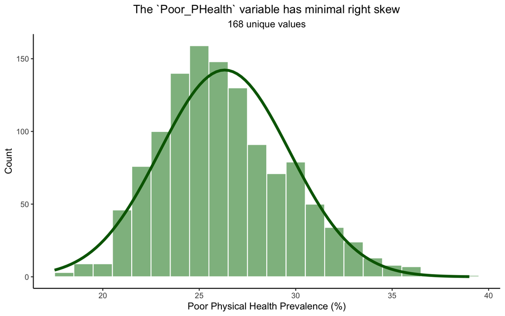

```r
unique_values <- length(unique(counties_sample$Poor_PHealth))

bin_w <- 1
res <- mosaic::fav_stats(counties_sample$Poor_PHealth)
hist_plot <-  ggplot(counties_sample, aes(x = Poor_PHealth)) +
  geom_histogram(binwidth = bin_w, color = "white", fill = "darkseagreen") +
  stat_function( # Plot Normal curve
        fun = function(x) dnorm(x, mean = res$mean,
                                sd = res$sd) *
            res$n * bin_w,
        col = "darkgreen", size = 1.5) +
  labs(title = "The `Poor_PHealth` variable has minimal right skew",
       subtitle = paste0(unique_values, " unique values"),
       x = "Poor Physical Health Prevalence (%)", y = "Count") +
  theme_classic() +
  theme(plot.title = element_text(hjust = 0.5),
        plot.subtitle = element_text(hjust = 0.5))

hist_plot
```

## 6.2 My Planned Predictors (Linear Model)

We will be using `Arthritis`, `Stroke`, `CKD`, and `Doc_Visit_Quar` as our input variables. As seen in the plots below, the `Arthritis`, `Stroke`, and `CKD` variables are quantitative, each with greater than 10 different, ordered, observed values. Additionally, the `Doc_Visit_Quar` categorical variable has 4 categories, each with more than 30 observations in each level of the factor. Finally, as we have 1200 samples, our four candidate predictors are below the limit of 15 regression inputs (using the 4 + (N-100)/100 formula).

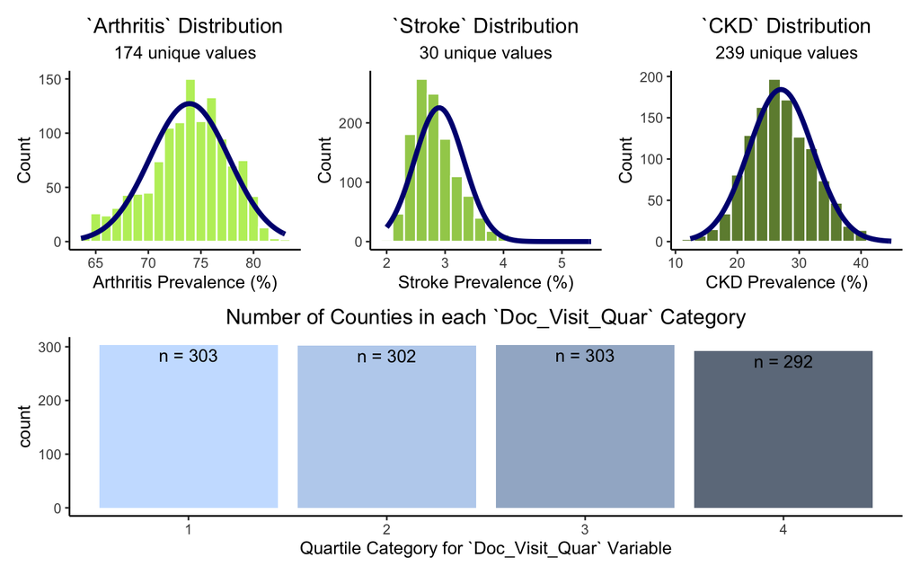

```r
unique_values <- length(unique(counties_sample$Arthritis)) # for plot subtitle

bin_w1 <- 1
res1 <- mosaic::fav_stats(counties_sample$Arthritis)
hist_plot_arthritis <-  ggplot(counties_sample, aes(x = Arthritis)) +
  geom_histogram(binwidth = bin_w1, color = "white", fill = "darkolivegreen2") +
  stat_function( # Plot Normal curve
        fun = function(x) dnorm(x, mean = res1$mean,
                                sd = res1$sd) *
            res1$n * bin_w1,
        col = "navyblue", size = 1.5) +
  labs(title = "`Arthritis` Distribution",
       subtitle = paste0(unique_values, " unique values"),
       x = "Arthritis Prevalence (%)", y = "Count") +
  theme_classic() +
  theme(plot.title = element_text(hjust = 0.5),
        plot.subtitle = element_text(hjust = 0.5))


unique_values <- length(unique(counties_sample$Stroke)) # for plot subtitle
bin_w2 <- 0.2
res2 <- mosaic::fav_stats(counties_sample$Stroke)
hist_plot_stroke <-  ggplot(counties_sample, aes(x = Stroke)) +
  geom_histogram(binwidth = bin_w2, color = "white", fill = "darkolivegreen3") +
  stat_function( # Plot Normal curve
        fun = function(x) dnorm(x, mean = res2$mean,
                                sd = res2$sd) *
            res2$n * bin_w2,
        col = "navyblue", size = 1.5) +
  labs(title = "`Stroke` Distribution",
       subtitle = paste0(unique_values, " unique values"),
       x = "Stroke Prevalence (%)", y = "Count") +
  theme_classic() +
  theme(plot.title = element_text(hjust = 0.5),
        plot.subtitle = element_text(hjust = 0.5))


unique_values <- length(unique(counties_sample$CKD)) # for plot subtitle
bin_w3 <- 2
res3 <- mosaic::fav_stats(counties_sample$CKD)
hist_plot_CKD <-  ggplot(counties_sample, aes(x = CKD)) +
  geom_histogram(binwidth = bin_w3, color = "white", fill = "darkolivegreen4") +
  stat_function( # Plot Normal curve
        fun = function(x) dnorm(x, mean = res3$mean,
                                sd = res3$sd) *
            res3$n * bin_w3,
        col = "navyblue", size = 1.5) +
  labs(title = "`CKD` Distribution",
       subtitle = paste0(unique_values, " unique values"),
       x = "CKD Prevalence (%)", y = "Count") +
  theme_classic() +
  theme(plot.title = element_text(hjust = 0.5),
        plot.subtitle = element_text(hjust = 0.5))


bar_plot_doc <- ggplot(counties_sample, aes(x = Doc_Visit_Quar, fill = Doc_Visit_Quar)) +
  geom_bar(stat = "count", fill = c("lightsteelblue1", "lightsteelblue2", "lightsteelblue3", "lightsteelblue4")) +
  labs(title = "Number of Counties in each `Doc_Visit_Quar` Category",
       x = "Quartile Category for `Doc_Visit_Quar` Variable") +
  theme_classic() +
  theme(legend.position = 0,
        plot.title = element_text(hjust = 0.5)) +
  geom_text(stat='count', aes(label=paste0("n = ", ..count..)), vjust=1.3)

(hist_plot_arthritis  + hist_plot_stroke + hist_plot_CKD) / bar_plot_doc
```

# 7 Logistic Regression Plans

Using logistic regression, I plan to assess whether prevalence of self-reported poor mental health for at least 14 days per month can be predicted by prevalence of no leisure-time exercise, limited sleep, poor physical health for the majority of the month, and binge drinking.

## 7.1 My Binary Outcome

This logistic regression will predict `Poor_MHealth_High`, which is a binary variable representing whether a county is above the median for prevalence of >=14 poor mental health days out of the last 30 days, where `0` = No and `1` = Yes. We’re using this variable as our outcome, because it is well known that the causes of poor mental health are multifactorial and I’m interested in assessing if there are any intriguing relationships with other health-related variables in our data set.

Below, we’ll group our data frame using `group_by` and `count` to show that there are 581 samples in the `0` category and 619 samples in the `1` category.

```r
counties_sample %>%
  group_by(Poor_MHealth_High) %>%
  count()
```

```
# A tibble: 2 x 2
# Groups:   Poor_MHealth_High [2]
  Poor_MHealth_High     n
  <ord>             <int>
1 0                   581
2 1                   619
```

## 7.2 My Planned Predictors (Logistic Model)

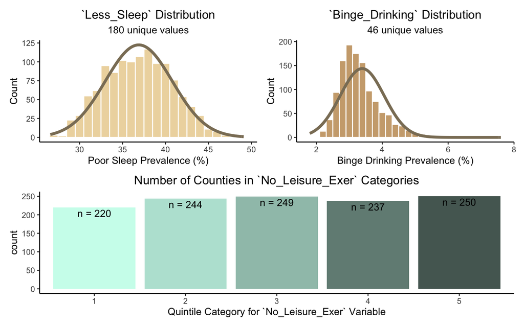

```r
unique_values <- length(unique(counties_sample$Less_Sleep)) # for plot subtitle
bin_w1 <- 1
res1 <- mosaic::fav_stats(counties_sample$Less_Sleep)
hist_plot_sleep <-  ggplot(counties_sample, aes(x = Less_Sleep)) +
  geom_histogram(binwidth = bin_w1, color = "white", fill = "wheat2") +
  stat_function( # Plot Normal curve
        fun = function(x) dnorm(x, mean = res1$mean,
                                sd = res1$sd) *
            res1$n * bin_w1,
        col = "wheat4", size = 1.5) +
  labs(title = "`Less_Sleep` Distribution",
       subtitle = paste0(unique_values, " unique values"),
       x = "Poor Sleep Prevalence (%)", y = "Count") +
  theme_classic() +
  theme(plot.title = element_text(hjust = 0.5),
        plot.subtitle = element_text(hjust = 0.5))


unique_values <- length(unique(counties_sample$Binge_Drinking)) # for plot subtitle
bin_w2 <- 0.2
res2 <- mosaic::fav_stats(counties_sample$Binge_Drinking)
hist_plot_binge <-  ggplot(counties_sample, aes(x = Binge_Drinking)) +
  geom_histogram(binwidth = bin_w2, color = "white", fill = "burlywood3") +
  stat_function( # Plot Normal curve
        fun = function(x) dnorm(x, mean = res2$mean,
                                sd = res2$sd) *
            res2$n * bin_w2,
        col = "wheat4", size = 1.5) +
  labs(title = "`Binge_Drinking` Distribution",
       subtitle = paste0(unique_values, " unique values"),
       x = "Binge Drinking Prevalence (%)", y = "Count") +
  theme_classic() +
  theme(plot.title = element_text(hjust = 0.5),
        plot.subtitle = element_text(hjust = 0.5))


bar_plot_exer <- ggplot(counties_sample, aes(x = No_Leisure_Exer_Quin, fill = No_Leisure_Exer_Quin)) +
  geom_bar(stat = "count", fill = c("#CDFCED", "#B9E3D6", "#9FC3B8", "#728C84", "#556762")) +
  labs(title = "Number of Counties in `No_Leisure_Exer` Categories",
       x = "Quintile Category for `No_Leisure_Exer` Variable") +
  theme_classic() +
  theme(legend.position = 0,
        plot.title = element_text(hjust = 0.5)) +
  geom_text(stat='count', aes(label=paste0("n = ", ..count..)), vjust=1.3)

(hist_plot_sleep + hist_plot_binge) / bar_plot_exer
```

# 8 Affirmation

I am certain that it is completely appropriate for these data to be shared with anyone, without any conditions. There are no concerns about privacy or security.

# 9 References

1. PLACES Project. Centers for Disease Control and Prevention. Accessed [2021/02/16]. https://www.cdc.gov/places
2. Zhang, X., Holt, J. B., Lu, H., Wheaton, A. G., Ford, E. S., Greenlund, K. J., & Croft, J. B. (2014). Multilevel regression and poststratification for small-area estimation of population health outcomes: a case study of chronic obstructive pulmonary disease prevalence using the behavioral risk factor surveillance system. *American journal of epidemiology*, 179(8), 1025-1033.
3. Zhang, X., Holt, J. B., Yun, S., Lu, H., Greenlund, K. J., & Croft, J. B. (2015). Validation of multilevel regression and poststratification methodology for small area estimation of health indicators from the behavioral risk factor surveillance system. *American journal of epidemiology*, 182(2), 127-137.